# Module 3 Theory: Finding Coefficients for Logistic regression

Author

John Mayberry

These notes require some familiarity with mathematical statistics and the idea of Maximum Likelihood Estimators (MLEs).

## MLEs for Parameters

Suppose that we have a sequence of binary 0/1 outcomes $Y_1,..,Y_n$ where the success probability for outcome $i$ is
$$\phi((X \beta)_i) = \frac{1}{1+e^{-(X \beta)_i}}$$
Because the parenthesis get out of control, we will write $\eta_i = (X\beta)_i$ for the rest of this section.

The likelihood function for the vector $\beta$ of coefficients is
$$L(\beta) = \prod_{i=1}^n [\phi(\eta_i)]^{y_i}[1- \phi(\eta_i)]^{1-y_i}$$
and the log likelihood is
$$\ell(\beta) = \sum y_i \log \phi(\eta_i) + (1-y_i) \log (1- \phi(\eta_i))$$
Taking derivatives with respect to $\beta_j$ gives

$$\frac{\partial \ell}{\partial \beta_j} = \sum y_i x_{ij}\phi'(\eta_i)/\phi(\eta_i) -x_{ij} (1-y_i) \phi'(\eta_i) /(1- \phi(\eta_i))$$

Now we use the fact that
$$\phi' = \phi(1-\phi)$$
to get
$$\frac{\partial \ell}{\partial \beta_j} = \sum y_i x_{ij} (1- \phi(\eta_i)) -x_{ij} (1-y_i) \phi(\eta_i) = \sum x_{ij} (y_i - \phi(\eta_i))$$

In vector form, it looks nicer:

$$\nabla \ell = X^T (y - \phi(X\beta))$$

Unfortunately, unlike with linear regression, there is no closed from solution to the equation $\nabla \ell = 0$ and hence you have to use numerical methods to solve for the MLEs of $\beta$. We’ll demonstrate this approach using gradient descent (since we already introduced this in the Module 1 Supplement) although Newton-Raphson also works nicely for this scenario.

## Gradient Descent Revisited

Recall that gradient descent is an optimization algorithm used to minimize a loss function by iteratively adjusting parameters. In this case, the loss function we want to minimize is
$$d = - 2 \log \ell$$
where $\ell$ is the log-likelihood. The negative is needed to turn the max into a min and the 2 is unnecessary but typically used because for a normal distribution
$$-2 \log \ell = \sum(y_i - \eta_i)^2$$
corresponds to the usual least squares loss function. The $d$ stands for deviance as this term is often called the residual deviance in logistic regression outputs.

We will demonstrate in the case where we only have a single predictor $X_1$ and generate some fake data to test the algorithm

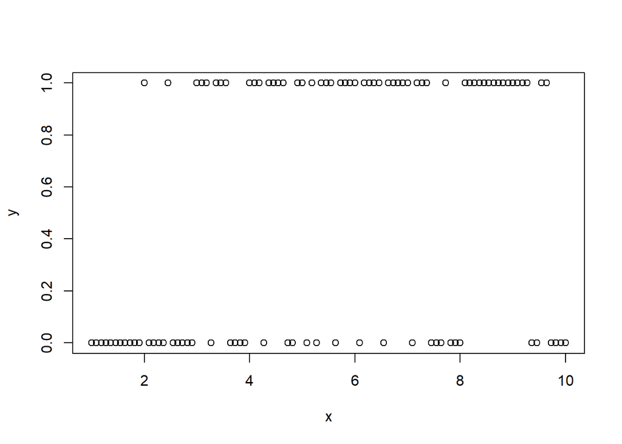

```r
set.seed(45)
n = 100
phi=function(x){
  1/(1+exp(-x))
}
x = seq(1, 10, length.out = n)
b1 = .25
b0 = -1
y = rbinom(n,1,prob=phi(b0+b1*x))
data = data.frame(x = x, y = y)
plot(data$x,data$y,xlab="x",ylab="y")
```

The partial derivatives of the loss function are:

$$\frac{\partial \ell}{\partial \beta_0}= -2\sum (y_i - \phi(\eta_i))$$
and

$$\frac{\partial \ell}{\partial \beta_1} = -2\sum x_i (y_i - \phi(\eta_i))$$
where $\eta_i = \beta_0 + \beta_1 x_$. Here is the R implementation

```r
gradient_descent = function(x, y, learning_rate = 0.01, epochs = 1000) {
  beta0 = 0 # Initial values give neutral p = 0.5
  beta1 = 0
  n = length(y) # Number of data points
  phi=function(x){
      1/(1+exp(-x))
    }

  for (i in 1:epochs) {
    # Predicted probs
    eta = phi(beta0 + beta1*x)

    # Gradients
    gradient_0= -2 *sum(y - eta)
    gradient_1 = -2 *sum(x*(y - eta))


    # Update parameters
    beta0 = beta0 - learning_rate * gradient_0
    beta1 = beta1 - learning_rate * gradient_1

  }

  return(list(beta0 = beta0, beta1 = beta1))
}

# Run gradient descent
gd_result <- gradient_descent(data$x, data$y, learning_rate = 0.001, epochs = 1000)
gd_result
```

```
$beta0
[1] -1.261175

$beta1
[1] 0.2618266
```

The results should roughly match those obtained by `glm`:

```r
glm(y~x,data=data,family="binomial")
```

```
Call:  glm(formula = y ~ x, family = "binomial", data = data)

Coefficients:
(Intercept)            x
    -1.2616       0.2619

Degrees of Freedom: 99 Total (i.e. Null);  98 Residual
Null Deviance:      138
Residual Deviance: 127.4    AIC: 131.4
```

I encourage you to play around with how convergence depends on the learning rate in this scenario!